# Cookie Cats: Does Moving the Level Gate Change Player Retention?

Significance, power, frequentist vs. Bayesian, and the cost of peeking early

## Executive Summary

Moving Cookie Cats’ progression gate from level 30 to level 40 reduced player retention. The effect was directionally visible but not conclusive on Day 1 alone, comfortably powered and statistically significant on Day 7, and consistent across a frequentist and a Bayesian reading of the same data.

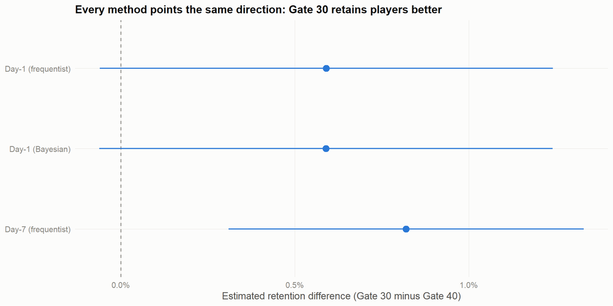

Figure 1: Estimated effect of Gate 30 vs Gate 40 (Gate 30 minus Gate 40), across every method used in this report

```r
gate30_n <- sum(cookie_cats$version == "gate_30")
gate40_n <- sum(cookie_cats$version == "gate_40")
gate30_ret1 <- sum(cookie_cats$retention_1[cookie_cats$version == "gate_30"])
gate40_ret1 <- sum(cookie_cats$retention_1[cookie_cats$version == "gate_40"])
gate30_ret7 <- sum(cookie_cats$retention_7[cookie_cats$version == "gate_30"])
gate40_ret7 <- sum(cookie_cats$retention_7[cookie_cats$version == "gate_40"])

ret1_test_summary <- prop.test(x = c(gate30_ret1, gate40_ret1), n = c(gate30_n, gate40_n))
ret7_test_summary <- prop.test(x = c(gate30_ret7, gate40_ret7), n = c(gate30_n, gate40_n))

set.seed(42)
n_draws <- 100000
post30 <- rbeta(n_draws, 1 + gate30_ret1, 1 + (gate30_n - gate30_ret1))
post40 <- rbeta(n_draws, 1 + gate40_ret1, 1 + (gate40_n - gate40_ret1))
post_diff <- post30 - post40

summary_estimates <- tibble(
  method = c("Day-1 (frequentist)", "Day-1 (Bayesian)", "Day-7 (frequentist)"),
  estimate = c(
    unname(ret1_test_summary$estimate[1] - ret1_test_summary$estimate[2]),
    mean(post_diff),
    unname(ret7_test_summary$estimate[1] - ret7_test_summary$estimate[2])
  ),
  ci_low = c(ret1_test_summary$conf.int[1], quantile(post_diff, 0.025), ret7_test_summary$conf.int[1]),
  ci_high = c(ret1_test_summary$conf.int[2], quantile(post_diff, 0.975), ret7_test_summary$conf.int[2])
)

summary_estimates |>
  mutate(method = factor(method, levels = rev(method))) |>
  ggplot(aes(x = estimate, y = method)) +
  geom_vline(xintercept = 0, linetype = "dashed", color = color_muted) +
  geom_pointrange(aes(xmin = ci_low, xmax = ci_high), color = color_sequential, linewidth = 0.8, size = 0.8) +
  scale_x_continuous(labels = percent_format(accuracy = 0.1)) +
  labs(
    x = "Estimated retention difference (Gate 30 minus Gate 40)", y = NULL,
    title = "Every method points the same direction: Gate 30 retains players better"
  )
```

Every method used in this report, the Day-1 z-test, the Day-1 Bayesian posterior, and the Day-7 z-test, estimates a positive effect for Gate 30, and none of their intervals meaningfully favor Gate 40. The Day-7 result, the most statistically decisive of the three, corresponds to roughly 820 more players per 100,000 installs still active a week after install under Gate 30 than under Gate 40.

The recommendation is to keep the progression gate at level 30 rather than move it to level 40. Two caveats apply. First, this analysis measures retention only; it does not account for in-app purchase revenue or longer-term engagement, either of which could shift the trade-off if gate placement affects them differently. Second, the Day-1 result alone was underpowered for the effect size actually observed (section 4); it is the Day-7 result, not the Day-1 result, that makes this recommendation statistically decisive rather than merely suggestive.

## 1 Introduction

Cookie Cats is a mobile puzzle game developed by Tactile Entertainment in the connect-three genre, where players clear boards of coloured pieces to earn stars and progress through a long sequence of numbered levels. Like most games in this genre, its core loop pairs short, replayable levels with a slow drip of new content, and its business model depends on players returning day after day rather than on a single upfront purchase.

A common mechanic in this genre is the level gate: at a specific level, progress is paused and the player must either wait for a timer to expire, ask friends for help, or make an in-app purchase to continue immediately. Gates serve two purposes at once. They create a natural pause point that can prompt social sharing or purchases, and they space out how quickly players consume content, extending how long the game holds each player’s attention. Placed too early, a gate can push players to quit before they are invested in the game. Placed too late, it may fail to create enough of a pause to be useful at all. Where to place it is therefore an empirical question, not something that can be reasoned out from first principles alone.

Cookie Cats originally placed its first gate at level 30. In this experiment, the gate was moved to level 40 for a randomly assigned half of new players, while the remaining half kept the level 30 gate, to test whether delaying the gate changed how many players kept playing the game.

This report evaluates the effect of that change on player retention and addresses five questions in sequence: whether retention actually changed, whether the experiment collected enough data to trust that result, how a frequentist and a Bayesian analysis of the same data compare, how much the false-positive rate would have inflated had the test been monitored and stopped early, and what the 7-day retention data confirms about the 1-day result.

## 2 Data

The dataset covers 90,189 players who installed Cookie Cats and were randomly assigned to one of the two gate positions (Sui 2019). Before drawing any conclusions from it, it is worth confirming that the random assignment produced two comparably sized groups, that the data is complete, and that player behaviour looks the way it should for a mobile game of this kind.

```r
group_counts <- cookie_cats |>
  count(version, name = "players")

group_counts |>
  mutate(version = recode(version, !!!gate_labels)) |>
  gt() |>
  cols_label(version = "Group", players = "Players") |>
  fmt_number(columns = players, decimals = 0) |>
  tab_header(title = "Players per group")
```

Players per group

| Group | Players |
| --- | --- |
| Gate 30 | 44,700 |
| Gate 40 | 45,489 |

The two groups are close to evenly split, consistent with a working randomisation process.

A quick missingness check confirms whether any column has gaps that would need to be handled before analysis.

```r
missing_counts <- colSums(is.na(cookie_cats))
missing_counts
```

```
        userid        version sum_gamerounds    retention_1    retention_7
             0              0              0              0              0
```

None of the columns have missing values, so no imputation or row removal is needed before proceeding.

Player behaviour within the game is heavily right-skewed: most players stop playing within a handful of rounds, while a small number play thousands of rounds. Because a meaningful share of players finish with zero rounds recorded, the chart below uses a pseudo-log transform rather than a standard log scale, which would otherwise drop those players from the plot entirely.

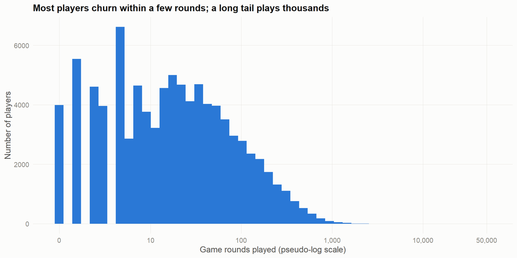

Figure 2: Distribution of game rounds played, pseudo-log scale

```r
cookie_cats |>
  ggplot(aes(x = sum_gamerounds)) +
  geom_histogram(bins = 50, fill = color_sequential) +
  scale_x_continuous(
    trans = scales::pseudo_log_trans(base = 10),
    breaks = c(0, 10, 100, 1000, 10000, 50000),
    labels = comma
  ) +
  labs(
    x = "Game rounds played (pseudo-log scale)",
    y = "Number of players",
    title = "Most players churn within a few rounds; a long tail plays thousands"
  )
```

This long tail is expected for a free-to-play mobile game and is not a data quality issue. A single extreme outlier, one player with just under 50,000 recorded rounds, sits far beyond the rest of the distribution but is retained in the analysis, since the retention metrics used in the sections that follow depend only on whether a player returned, not on how many rounds they played.

## 3 Did It Work?

The first and most direct question is whether moving the gate changed Day-1 retention. The rate for each group is computed with a 95% confidence interval using the normal approximation to the binomial, so the size of the gap can be judged against its uncertainty before any formal test is run.

```r
retention_summary <- function(data, retention_col) {
  data |>
    group_by(version) |>
    summarise(
      n = n(),
      retained = sum(.data[[retention_col]]),
      rate = retained / n,
      se = sqrt(rate * (1 - rate) / n),
      ci_low = rate - 1.96 * se,
      ci_high = rate + 1.96 * se,
      .groups = "drop"
    )
}

ret1_summary <- retention_summary(cookie_cats, "retention_1")

ret1_summary |>
  mutate(version = recode(version, !!!gate_labels)) |>
  gt() |>
  cols_label(
    version = "Group", n = "Players", retained = "Retained (Day 1)",
    rate = "Retention rate", ci_low = "95% CI low", ci_high = "95% CI high"
  ) |>
  fmt_percent(columns = c(rate, ci_low, ci_high), decimals = 2) |>
  fmt_number(columns = c(n, retained), decimals = 0) |>
  tab_header(title = "Day-1 retention by group")
```

Day-1 retention by group

| Group | Players | Retained (Day 1) | Retention rate | se | 95% CI low | 95% CI high |
| --- | --- | --- | --- | --- | --- | --- |
| Gate 30 | 44,700 | 20,034 | 44.82% | 0.002352187 | 44.36% | 45.28% |
| Gate 40 | 45,489 | 20,119 | 44.23% | 0.002328648 | 43.77% | 44.68% |

The chart below makes the size of the gap, and its uncertainty, visible at a glance before any test statistic is computed.

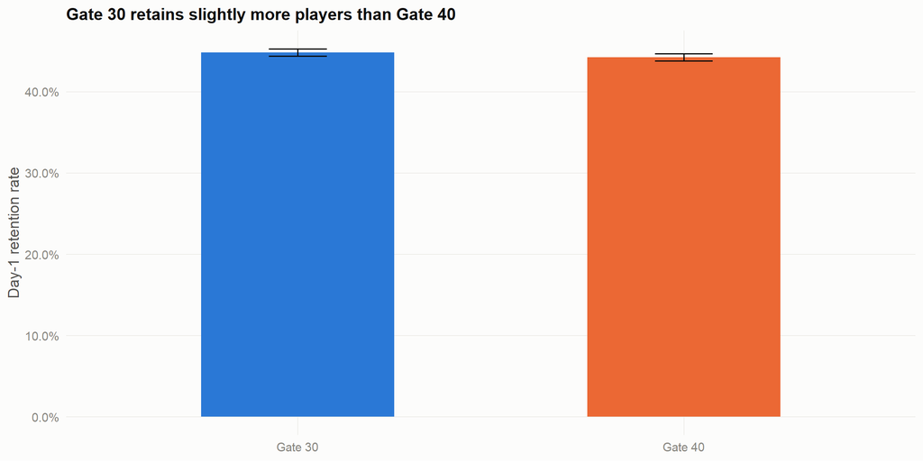

Figure 3: Day-1 retention rate by gate placement, with 95% confidence intervals

```r
ret1_summary |>
  ggplot(aes(x = version, y = rate, fill = version)) +
  geom_col(width = 0.5) +
  geom_errorbar(aes(ymin = ci_low, ymax = ci_high), width = 0.15, color = color_primary_ink) +
  scale_y_continuous(labels = percent_format(accuracy = 0.1)) +
  scale_x_gate() +
  scale_fill_gate() +
  labs(
    x = NULL, y = "Day-1 retention rate",
    title = "Gate 30 retains slightly more players than Gate 40"
  ) +
  theme(legend.position = "none")
```

A two-proportion z-test formalises whether the gap seen in the chart is larger than would be expected from random noise alone.

```r
ret1_test <- prop.test(
  x = c(
    sum(cookie_cats$retention_1[cookie_cats$version == "gate_30"]),
    sum(cookie_cats$retention_1[cookie_cats$version == "gate_40"])
  ),
  n = c(
    sum(cookie_cats$version == "gate_30"),
    sum(cookie_cats$version == "gate_40")
  )
)

tidy(ret1_test) |>
  transmute(
    `Gate 30 rate` = estimate1,
    `Gate 40 rate` = estimate2,
    Difference = estimate1 - estimate2,
    `Test statistic (z²)` = statistic,
    df = parameter,
    `p-value` = p.value,
    `95% CI low` = conf.low,
    `95% CI high` = conf.high
  ) |>
  gt() |>
  fmt_percent(columns = c(`Gate 30 rate`, `Gate 40 rate`, Difference, `95% CI low`, `95% CI high`), decimals = 2) |>
  fmt_number(columns = `Test statistic (z²)`, decimals = 2) |>
  fmt_number(columns = df, decimals = 0) |>
  fmt_number(columns = `p-value`, decimals = 3) |>
  tab_header(title = "Two-proportion z-test: Day-1 retention") |>
  tab_source_note(source_note = "R's prop.test() reports the chi-square statistic for a 2x2 test, which is algebraically equivalent to the square of the two-proportion z-statistic.")
```

Two-proportion z-test: Day-1 retention

| Gate 30 rate | Gate 40 rate | Difference | Test statistic (z²) | df | p-value | 95% CI low | 95% CI high |
| --- | --- | --- | --- | --- | --- | --- | --- |
| 44.82% | 44.23% | 0.59% | 3.16 | 1 | 0.076 | −0.06% | 1.24% |

R's prop.test() reports the chi-square statistic for a 2x2 test, which is algebraically equivalent to the square of the two-proportion z-statistic.

The p-value from this test is 0.076, which does not clear the conventional 0.05 threshold. Taken on its own, the Day-1 result is directionally consistent with gate_30 retaining players better, but is not conclusive by the standard significance convention. The next two sections examine whether that inconclusiveness is a matter of insufficient data or a genuine absence of a strong effect, and section 7 checks whether the 7-day data tells a clearer story.

## 4 Statistical Power

A result that falls short of significance is only informative once it is clear whether the experiment had enough players to reliably detect an effect of this size in the first place. This section quantifies that using the standard 80% power, alpha 0.05 convention (Cohen 1988), applied to the effect size actually observed between the two groups.

```r
p1 <- ret1_summary$rate[ret1_summary$version == "gate_30"]
p2 <- ret1_summary$rate[ret1_summary$version == "gate_40"]
effect_h <- ES.h(p1, p2)

actual_n_per_group <- mean(ret1_summary$n)

achieved_power <- pwr.2p.test(h = effect_h, n = actual_n_per_group, sig.level = 0.05)
required_n_for_80pct <- pwr.2p.test(h = effect_h, power = 0.8, sig.level = 0.05)

tibble(
  Scenario = c("Achieved (actual sample size)", "Required for 80% power"),
  `Sample size per group` = c(achieved_power$n, required_n_for_80pct$n),
  Power = c(achieved_power$power, required_n_for_80pct$power)
) |>
  gt() |>
  fmt_number(columns = `Sample size per group`, decimals = 0) |>
  fmt_percent(columns = Power, decimals = 1) |>
  tab_header(title = "Power analysis for the observed effect") |>
  tab_source_note(source_note = paste0("Effect size (Cohen's h): ", round(effect_h, 4), ", significance level: 0.05"))
```

Power analysis for the observed effect

| Scenario | Sample size per group | Power |
| --- | --- | --- |
| Achieved (actual sample size) | 45,095 | 43.0% |
| Required for 80% power | 111,190 | 80.0% |

Effect size (Cohen's h): 0.0119, significance level: 0.05

The observed effect size (Cohen’s h) between the two groups is small, about 0.012. At the actual sample size of roughly 45,000 players per group, the experiment had only a 43% chance of detecting an effect this small at the 0.05 significance level, well short of the 80% convention. Reaching 80% power for an effect this small would have required roughly 111,000 players per group, close to two and a half times what was actually collected. This is the direct explanation for the inconclusive Day-1 result in the previous section: the experiment was not underpowered because of a mistake, but because the true effect on Day-1 retention turns out to be smaller than the experiment was sized to detect reliably.

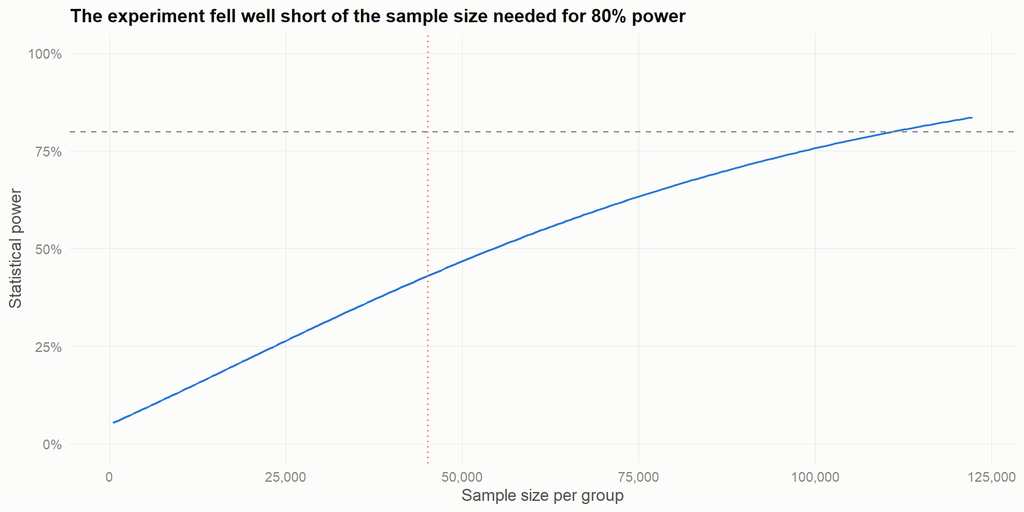

Figure 4: Statistical power to detect the observed effect size as sample size grows

```r
power_curve_data <- tibble(n = seq(500, required_n_for_80pct$n * 1.1, length.out = 200)) |>
  mutate(power = map_dbl(n, \(n) pwr.2p.test(h = effect_h, n = n, sig.level = 0.05)$power))

power_curve_data |>
  ggplot(aes(x = n, y = power)) +
  geom_line(color = color_sequential, linewidth = 0.8) +
  geom_hline(yintercept = 0.8, linetype = "dashed", color = color_muted) +
  geom_vline(xintercept = actual_n_per_group, linetype = "dotted", color = color_gate40) +
  scale_y_continuous(labels = percent_format(), limits = c(0, 1)) +
  scale_x_continuous(labels = comma) +
  labs(
    x = "Sample size per group", y = "Statistical power",
    title = "The experiment fell well short of the sample size needed for 80% power"
  )
```

The dotted vertical line marks the actual sample size the experiment collected; the dashed horizontal line marks the 80% power convention. The experiment would have needed to run substantially longer, or recruit a larger share of new players, to reliably detect an effect of this size on Day-1 retention alone.

## 5 Frequentist vs Bayesian

The Day-1 result leaves two ways to describe the same evidence. A frequentist reading, like the z-test above, asks how often data this extreme would arise if there were truly no difference between the groups, and reports a p-value against a fixed threshold, in this case one that falls just short of 0.05. A Bayesian reading instead asks directly: given the data observed, how likely is it that gate_30 truly retains players better than gate_40? These are different questions, and a team can reasonably disagree about which one is more useful to answer, but they can be answered from the same data without contradiction.

A beta-binomial model with a flat, uninformative Beta(1,1) prior, meaning no assumption is made about the retention rate before seeing the data, gives a direct answer to the Bayesian question. Each group’s posterior distribution over its true retention rate is sampled with `rbeta()`.

```r
set.seed(42)
n_draws <- 100000

gate30_successes <- sum(cookie_cats$retention_1[cookie_cats$version == "gate_30"])
gate30_n <- sum(cookie_cats$version == "gate_30")
gate40_successes <- sum(cookie_cats$retention_1[cookie_cats$version == "gate_40"])
gate40_n <- sum(cookie_cats$version == "gate_40")

posterior_gate30 <- rbeta(n_draws, 1 + gate30_successes, 1 + (gate30_n - gate30_successes))
posterior_gate40 <- rbeta(n_draws, 1 + gate40_successes, 1 + (gate40_n - gate40_successes))

posterior_diff <- posterior_gate30 - posterior_gate40
prob_gate30_better <- mean(posterior_diff > 0)

tibble(
  Quantity = c("P(Gate 30 > Gate 40)", "Mean difference (Gate 30 minus Gate 40)", "95% credible interval"),
  Value = c(
    percent(prob_gate30_better, accuracy = 0.1),
    percent(mean(posterior_diff), accuracy = 0.01),
    paste0(percent(quantile(posterior_diff, 0.025), accuracy = 0.01), " to ", percent(quantile(posterior_diff, 0.975), accuracy = 0.01))
  )
) |>
  gt() |>
  tab_header(title = "Posterior summary: Day-1 retention difference")
```

Posterior summary: Day-1 retention difference

| Quantity | Value |
| --- | --- |
| P(Gate 30 > Gate 40) | 96.2% |
| Mean difference (Gate 30 minus Gate 40) | 0.59% |
| 95% credible interval | -0.06% to 1.24% |

The chart below shows the full posterior distribution for each group’s retention rate. The less these two distributions overlap, the more confident the data makes us that the groups genuinely differ.

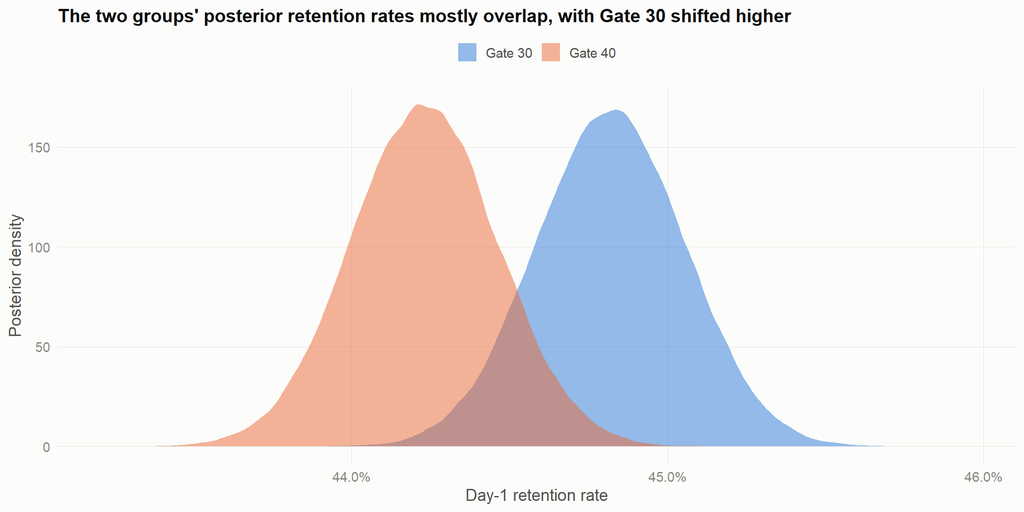

Figure 5: Posterior distributions of Day-1 retention rate for each group

```r
tibble(
  rate = c(posterior_gate30, posterior_gate40),
  version = rep(c("gate_30", "gate_40"), each = n_draws)
) |>
  ggplot(aes(x = rate, fill = version)) +
  geom_density(alpha = 0.5, color = NA) +
  scale_x_continuous(labels = percent_format(accuracy = 0.1)) +
  scale_fill_gate() +
  labs(
    x = "Day-1 retention rate", y = "Posterior density",
    title = "The two groups' posterior retention rates mostly overlap, with Gate 30 shifted higher"
  )
```

Under this model, there is a 96.2% probability that Gate 30’s true Day-1 retention rate is higher than Gate 40’s, with a mean estimated difference of about 0.6 percentage points. This is not a contradiction of the frequentist result: a p-value of 0.076 and a posterior probability of 96.2% are two framings of the same moderate, not-quite-conclusive evidence. The frequentist test asks whether the evidence clears an arbitrary fixed bar; the Bayesian model instead quantifies how confident the data alone makes us, which in this case is fairly confident, but not overwhelmingly so. Both readings agree on the same underlying fact: the data leans toward Gate 30, but not by a wide enough margin to rule out chance with high confidence from the Day-1 metric alone.

## 6 The Risk of Peeking

A separate risk sits alongside the significance question: if the team had checked the p-value every day of the experiment and stopped the moment it crossed 0.05, the true chance of a false alarm is much higher than 5%, even when there is truly no difference between the groups. This is simulated directly. Many independent experiments are run under the null hypothesis, both groups given the same true retention rate drawn from the pooled data, checking significance daily, to see how often a false alarm would have been triggered by some day in the experiment.

```r
set.seed(123)
sim_runs <- 1000
sim_days <- 45
daily_n_per_group <- round(actual_n_per_group / sim_days)
null_true_rate <- mean(cookie_cats$retention_1)

simulate_one_run <- function(run_id) {
  cum_a_success <- 0
  cum_a_n <- 0
  cum_b_success <- 0
  cum_b_n <- 0
  day_of_first_significance <- NA_integer_

  for (day in seq_len(sim_days)) {
    cum_a_n <- cum_a_n + daily_n_per_group
    cum_b_n <- cum_b_n + daily_n_per_group
    cum_a_success <- cum_a_success + rbinom(1, daily_n_per_group, null_true_rate)
    cum_b_success <- cum_b_success + rbinom(1, daily_n_per_group, null_true_rate)

    day_p_value <- prop.test(
      x = c(cum_a_success, cum_b_success),
      n = c(cum_a_n, cum_b_n)
    )$p.value

    if (is.na(day_of_first_significance) && day_p_value < 0.05) {
      day_of_first_significance <- day
    }
  }

  tibble(run_id = run_id, day_of_first_significance = day_of_first_significance)
}

peeking_results <- map_dfr(seq_len(sim_runs), simulate_one_run)
peeking_false_positive_rate <- mean(!is.na(peeking_results$day_of_first_significance))

tibble(
  Monitoring = c("Single look at the end", "Checked every day, stopped at first significance"),
  `False-positive rate` = c(0.05, peeking_false_positive_rate)
) |>
  gt() |>
  fmt_percent(columns = `False-positive rate`, decimals = 1) |>
  tab_header(title = "Effect of daily peeking on the false-positive rate") |>
  tab_source_note(source_note = paste0(sim_runs, " simulated null-hypothesis experiments, ", sim_days, " days of daily accrual each"))
```

Effect of daily peeking on the false-positive rate

| Monitoring | False-positive rate |
| --- | --- |
| Single look at the end | 5.0% |
| Checked every day, stopped at first significance | 27.8% |

1000 simulated null-hypothesis experiments, 45 days of daily accrual each

Checking once at a predetermined endpoint gives a false-positive rate matching the nominal 5%, as it should under the null hypothesis (Miller 2010). Checking every day and stopping at the first significant result instead pushes the false-positive rate to 27.8%, more than five times higher, using the exact same total amount of data. The chart below tracks, day by day, what fraction of the simulated null experiments have triggered at least one false alarm so far.

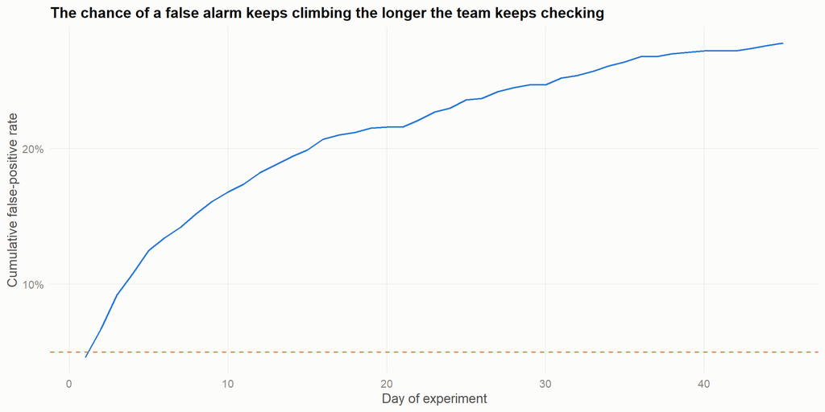

Figure 6: Peeking daily inflates the false-positive rate well beyond the nominal 5%

```r
cumulative_false_positive <- tibble(day = seq_len(sim_days)) |>
  mutate(
    cumulative_rate = map_dbl(day, \(d) {
      mean(!is.na(peeking_results$day_of_first_significance) &
        peeking_results$day_of_first_significance <= d)
    })
  )

cumulative_false_positive |>
  ggplot(aes(x = day, y = cumulative_rate)) +
  geom_line(color = color_sequential, linewidth = 0.8) +
  geom_hline(yintercept = 0.05, linetype = "dashed", color = color_gate40) +
  scale_y_continuous(labels = percent_format()) +
  labs(
    x = "Day of experiment", y = "Cumulative false-positive rate",
    title = "The chance of a false alarm keeps climbing the longer the team keeps checking"
  )
```

By the end of the simulated 45-day window, cumulative false alarms have climbed well past the dashed 5% reference line. This is the practical cost of monitoring a test daily and stopping as soon as the result looks good: it does not matter that no real effect exists in this simulation, since checking often enough will eventually produce a spurious “significant” result by chance alone. The Day-1 result in section 3 was checked once, at the end of the full dataset, so this specific risk does not apply to the number already reported, but it is a real risk for how the underlying experiment was likely monitored while it was running, and a reason to treat any test stopped early on a promising-looking p-value with real caution.

## 7 Day-7 Retention: A Confirmatory Check

```r
ret7_summary <- retention_summary(cookie_cats, "retention_7")

ret7_summary |>
  mutate(version = recode(version, !!!gate_labels)) |>
  gt() |>
  cols_label(
    version = "Group", n = "Players", retained = "Retained (Day 7)",
    rate = "Retention rate", ci_low = "95% CI low", ci_high = "95% CI high"
  ) |>
  fmt_percent(columns = c(rate, ci_low, ci_high), decimals = 2) |>
  fmt_number(columns = c(n, retained), decimals = 0) |>
  tab_header(title = "Day-7 retention by group")
```

Day-7 retention by group

| Group | Players | Retained (Day 7) | Retention rate | se | 95% CI low | 95% CI high |
| --- | --- | --- | --- | --- | --- | --- |
| Gate 30 | 44,700 | 8,502 | 19.02% | 0.001856272 | 18.66% | 19.38% |
| Gate 40 | 45,489 | 8,279 | 18.20% | 0.001809086 | 17.85% | 18.55% |

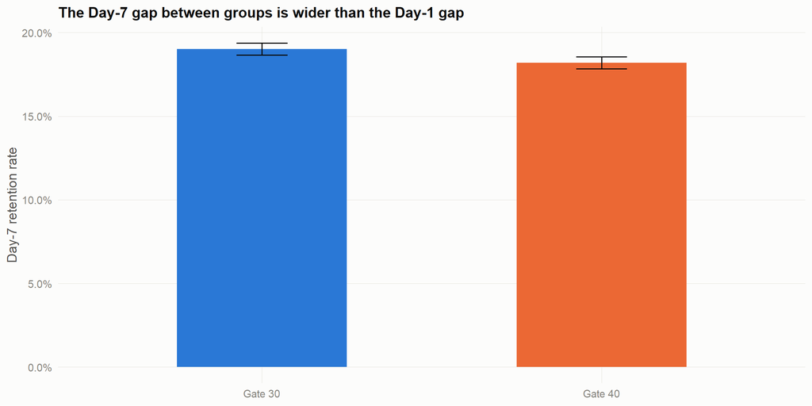

Figure 7: Day-7 retention rate by gate placement, with 95% confidence intervals

```r
ret7_summary |>
  ggplot(aes(x = version, y = rate, fill = version)) +
  geom_col(width = 0.5) +
  geom_errorbar(aes(ymin = ci_low, ymax = ci_high), width = 0.15, color = color_primary_ink) +
  scale_y_continuous(labels = percent_format(accuracy = 0.1)) +
  scale_x_gate() +
  scale_fill_gate() +
  labs(
    x = NULL, y = "Day-7 retention rate",
    title = "The Day-7 gap between groups is wider than the Day-1 gap"
  ) +
  theme(legend.position = "none")
```

```r
ret7_test <- prop.test(
  x = c(
    sum(cookie_cats$retention_7[cookie_cats$version == "gate_30"]),
    sum(cookie_cats$retention_7[cookie_cats$version == "gate_40"])
  ),
  n = c(
    sum(cookie_cats$version == "gate_30"),
    sum(cookie_cats$version == "gate_40")
  )
)

tidy(ret7_test) |>
  transmute(
    `Gate 30 rate` = estimate1,
    `Gate 40 rate` = estimate2,
    Difference = estimate1 - estimate2,
    `Test statistic (z²)` = statistic,
    df = parameter,
    `p-value` = p.value,
    `95% CI low` = conf.low,
    `95% CI high` = conf.high
  ) |>
  gt() |>
  fmt_percent(columns = c(`Gate 30 rate`, `Gate 40 rate`, Difference, `95% CI low`, `95% CI high`), decimals = 2) |>
  fmt_number(columns = `Test statistic (z²)`, decimals = 2) |>
  fmt_number(columns = df, decimals = 0) |>
  fmt_number(columns = `p-value`, decimals = 4) |>
  tab_header(title = "Two-proportion z-test: Day-7 retention") |>
  tab_source_note(source_note = "R's prop.test() reports the chi-square statistic for a 2x2 test, which is algebraically equivalent to the square of the two-proportion z-statistic.")
```

Two-proportion z-test: Day-7 retention

| Gate 30 rate | Gate 40 rate | Difference | Test statistic (z²) | df | p-value | 95% CI low | 95% CI high |
| --- | --- | --- | --- | --- | --- | --- | --- |
| 19.02% | 18.20% | 0.82% | 9.96 | 1 | 0.0016 | 0.31% | 1.33% |

R's prop.test() reports the chi-square statistic for a 2x2 test, which is algebraically equivalent to the square of the two-proportion z-statistic.

Testing two pre-specified endpoints, Day-1 and Day-7, carries its own multiplicity risk, distinct from the sequential peeking examined in section 6: peeking inflates false positives from checking one endpoint repeatedly over time, while testing two endpoints inflates the chance that at least one of them looks significant by chance, even with a single look at each. Applying a Bonferroni correction for two tests (alpha = 0.025 per test instead of 0.05) still leaves the Day-7 result significant (p = 0.0016), so this confirmation is not an artifact of having tested two metrics.

Section 4 showed the Day-1 test was underpowered for the effect size actually observed there. The same check is worth running on the Day-7 effect size, rather than assuming the significant p-value above implies adequate power.

```r
p1_day7 <- ret7_summary$rate[ret7_summary$version == "gate_30"]
p2_day7 <- ret7_summary$rate[ret7_summary$version == "gate_40"]
effect_h_day7 <- ES.h(p1_day7, p2_day7)

achieved_power_day7 <- pwr.2p.test(h = effect_h_day7, n = actual_n_per_group, sig.level = 0.05)
```

This effect size corresponds to an estimated power of 88.6%, well above the 43% achieved for Day-1 (section 4). The Day-7 effect is both larger in absolute terms and, because it is measured against a lower base retention rate, larger still on the arcsine scale power analysis uses, which is why the same sample size that left Day-1 underpowered comfortably powers Day-7.

## References

Cohen, Jacob. 1988. *Statistical Power Analysis for the Behavioral Sciences*. 2nd ed. Lawrence Erlbaum Associates.

Miller, Evan. 2010. “How Not to Run an a/b Test.” 2010. https://www.evanmiller.org/how-not-to-run-an-ab-test.html.

Sui, Yufeng. 2019. “Mobile Games a/b Testing: Cookie Cats.” Kaggle. https://www.kaggle.com/datasets/yufengsui/mobile-games-ab-testing.